# Regresión Lineal

## Introducción

[figure not shown]

**El análisis de regresión es uno de los más usados para analizar y predecir datos, pero ¿en qué consiste?**

Es una de las técnicas estadísticas más usadas para modelar la relación entre variables (Montgomery, D. C., entre otros, 2002); así mismo es útil para ser aplicada en muchas áreas diferentes a la estadística. Usa como principal herramienta estadística los mínimos cuadrados ordinarios, los cuales minimizan la suma de la distancia entre los valores observaos y teóricos. Además, permiten encontrar los mejores estimadores lineales insesgados.

## Historia

El primero en interesarse en modelar la relación entre variables fue Adolphe Quetelet en el siglo XIX, considerando la dispersión de los datos. En 1889 Francis Galton introdujo el término regresión en su libro *Natural inheritance,* donde, por medio de investigaciones empíricas, estudió la variablidad de características humanas (descripción de los datos físicos de los descendientes). Todo esto sin conocer suficientemente los métodos de la época.

Sin embargo, años antes (en 1805) Legendre documentó el método de mínimos cuadrados, debido a los trabajos de él y Gauss para ajustar los datos sobre las órbitas de cuerpos celestes; de donde se deriva la idea de regresión. En 1829 Gauss encontró que esta técnica de optimización es muy adecuada (siempre y cuando se tenga en cuenta la independencia de eventos); lo que lo llevó a establecer el teorema de Gauss Markov que muestra que los estimadores obtenidos con este método son insesgados y no se requiere una distribución específica para los datos que se ajustan.

Puede ahondar y profundizar en el tema [aquí](https://core.ac.uk/download/pdf/20343739.pdf).

## Algoritmo

La relación lineal entre las variables viene dada por la ecuación de una recta, como sigue:

En particular, el modelo de regresión lineal simple viene dado por la fórmula

$$y= \beta_0 + \beta_1 x + \epsilon$$

,donde $y$ es la variable respuesta y $x$ es la variable regresora.

Así mismo, el coeficiente $\beta_0$ se denomina intercepto, $\beta_1$ hace referencia a la inclinación de la línea regresor (es decir, la pendiente) y $\epsilon$ es el error estadístico (el ruido que se genera ya que el modelo no se ajusta exactamente a los datos).

En general, el modelo de regresión lineal múltiple viene dado por la fórmula

$$y= \beta_0 + \beta_1 x_1 + \beta_2 x_2 + ... + \beta_k x_k + \epsilon$$

,donde $y$ es la variable respuesta y las $x_i$ son las variables regresoras, con $i=1,2,....k$, y los coeficientes $\beta_0$, $\beta_1$, $\beta_2$, ... , $\beta_k$ son los parámetros del modelo.

## Implementación

### Datos de carros usados

Los datos fueron obtenidos de la página web de kaggle, el cual contiene características correspondientes a 100.000 carros usados de distintas marcas en Reino Unido ([Aquí se pueden encontrar](https://www.kaggle.com/adityadesai13/used-car-dataset-ford-and-mercedes)). Para este ejercicio, se tendrán en cuenta únicamente los carros de marca audi.

```python
import pandas as pd
import numpy as np
import matplotlib as plt
import seaborn as sns
import glob
import os
from IPython.display import Image
from IPython.core.display import HTML
```

```python
#Lectura de los datos
path ='audi.csv'
data = pd.read_csv(path)
data.head(5)
```

|  | model | year | price | transmission | mileage | fuelType | tax | mpg | engineSize |
| --- | --- | --- | --- | --- | --- | --- | --- | --- | --- |
| 0 | A1 | 2017 | 12500 | Manual | 15735 | Petrol | 150 | 55.4 | 1.4 |
| 1 | A6 | 2016 | 16500 | Automatic | 36203 | Diesel | 20 | 64.2 | 2.0 |
| 2 | A1 | 2016 | 11000 | Manual | 29946 | Petrol | 30 | 55.4 | 1.4 |
| 3 | A4 | 2017 | 16800 | Automatic | 25952 | Diesel | 145 | 67.3 | 2.0 |
| 4 | A3 | 2019 | 17300 | Manual | 1998 | Petrol | 145 | 49.6 | 1.0 |

```python
#Dimensión de los datos
print('\033[1m',"Dimensión de los datos")
print('\033[0m',"Los datos tienen", data.shape[0], "valores únicos y", data.shape[1], "variables.")
print("____________________________________________________")
#Clase de los objetos
print('\033[1m',"Clase de los objetos")
print('\033[0m',data.dtypes)
```

```
 Dimensión de los datos
 Los datos tienen 10668 valores únicos y 9 variables.
____________________________________________________
 Clase de los objetos
 model            object
year              int64
price             int64
transmission     object
mileage           int64
fuelType         object
tax               int64
mpg             float64
engineSize      float64
dtype: object
```

```python
print('\033[1m',"Variables categóricas")
print('\033[1m',"Modelo:", '\033[0m',data['model'].unique())
print('\033[1m',"Año:", '\033[0m', data['year'].unique())
print('\033[1m',"Transmisión:",'\033[0m', data['transmission'].unique())
print('\033[1m',"Tipo de combustible:",'\033[0m', data['fuelType'].unique())
```

```
 Variables categóricas
 Modelo:  [' A1' ' A6' ' A4' ' A3' ' Q3' ' Q5' ' A5' ' S4' ' Q2' ' A7' ' TT' ' Q7'
 ' RS6' ' RS3' ' A8' ' Q8' ' RS4' ' RS5' ' R8' ' SQ5' ' S8' ' SQ7' ' S3'
 ' S5' ' A2' ' RS7']
 Año:  [2017 2016 2019 2015 2014 2018 2013 2020 2004 2009 2012 2010 2007 2011
 2008 2003 2005 2002 2006 1998 1997]
 Transmisión:  ['Manual' 'Automatic' 'Semi-Auto']
 Tipo de combustible:  ['Petrol' 'Diesel' 'Hybrid']
```

Debido a que hay variables categóricas en el conjunto de datos, se hará uso de *one hot enconding* para poder usarlas en el modelo de regresión múltiple.

```python
print('\033[1m',"Modelo")
print('\033[0m',data['model'].value_counts())
print('\033[1m',"Transmisión")
print('\033[0m',data['transmission'].value_counts())
print('\033[1m',"Tipo de combustible")
print('\033[0m',data['fuelType'].value_counts())
```

```
 Modelo
  A3     1929
 Q3     1417
 A4     1381
 A1     1347
 A5      882
 Q5      877
 Q2      822
 A6      748
 Q7      397
 TT      336
 A7      122
 A8      118
 Q8       69
 RS6      39
 RS3      33
 RS4      31
 RS5      29
 R8       28
 S3       18
 SQ5      16
 S4       12
 SQ7       8
 S8        4
 S5        3
 A2        1
 RS7       1
Name: model, dtype: int64
 Transmisión
 Manual       4369
Semi-Auto    3591
Automatic    2708
Name: transmission, dtype: int64
 Tipo de combustible
 Diesel    5577
Petrol    5063
Hybrid      28
Name: fuelType, dtype: int64
```

```python
#Variables dummies para las tres variables categóricas
final_data = pd.get_dummies(data, columns=['model','transmission','fuelType'])
final_data.head()
```

|  | year | price | mileage | tax | mpg | engineSize | model_ A1 | model_ A2 | model_ A3 | model_ A4 | ... | model_ S8 | model_ SQ5 | model_ SQ7 | model_ TT | transmission_Automatic | transmission_Manual | transmission_Semi-Auto | fuelType_Diesel | fuelType_Hybrid | fuelType_Petrol |
| --- | --- | --- | --- | --- | --- | --- | --- | --- | --- | --- | --- | --- | --- | --- | --- | --- | --- | --- | --- | --- | --- |
| 0 | 2017 | 12500 | 15735 | 150 | 55.4 | 1.4 | 1 | 0 | 0 | 0 | ... | 0 | 0 | 0 | 0 | 0 | 1 | 0 | 0 | 0 | 1 |
| 1 | 2016 | 16500 | 36203 | 20 | 64.2 | 2.0 | 0 | 0 | 0 | 0 | ... | 0 | 0 | 0 | 0 | 1 | 0 | 0 | 1 | 0 | 0 |
| 2 | 2016 | 11000 | 29946 | 30 | 55.4 | 1.4 | 1 | 0 | 0 | 0 | ... | 0 | 0 | 0 | 0 | 0 | 1 | 0 | 0 | 0 | 1 |
| 3 | 2017 | 16800 | 25952 | 145 | 67.3 | 2.0 | 0 | 0 | 0 | 1 | ... | 0 | 0 | 0 | 0 | 1 | 0 | 0 | 1 | 0 | 0 |
| 4 | 2019 | 17300 | 1998 | 145 | 49.6 | 1.0 | 0 | 0 | 1 | 0 | ... | 0 | 0 | 0 | 0 | 0 | 1 | 0 | 0 | 0 | 1 |

5 rows × 38 columns

```
 Correlación entre variables numéricas
Variable respuesta:  Price
```

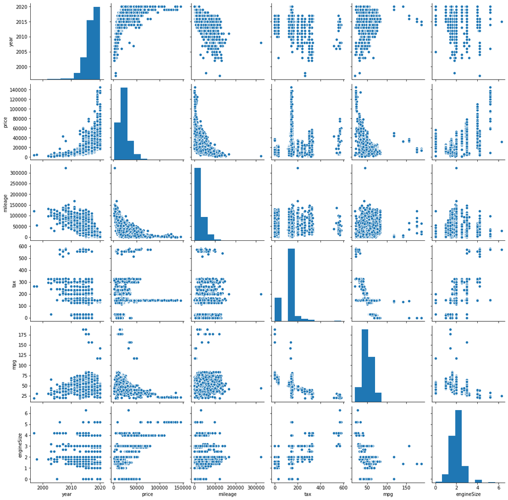

```python
print('\033[1m',"Correlación entre variables numéricas")
print("Variable respuesta:", '\033[0m', "Price")
sns.pairplot(data)
```

**Modelo de regresión lineal múltiple**

```python
import statsmodels.api as sm

final_data = sm.tools.tools.add_constant(final_data, prepend=True, has_constant='skip')

X = final_data.drop(['price'], axis = 1)
Y = final_data['price']

regressor = sm.OLS(Y,X).fit()
print(regressor.summary())
```

```
                            OLS Regression Results
==============================================================================
Dep. Variable:                  price   R-squared:                       0.892
Model:                            OLS   Adj. R-squared:                  0.891
Method:                 Least Squares   F-statistic:                     2577.
Date:                Sat, 13 Mar 2021   Prob (F-statistic):               0.00
Time:                        21:13:59   Log-Likelihood:            -1.0322e+05
No. Observations:               10668   AIC:                         2.065e+05
Df Residuals:                   10633   BIC:                         2.068e+05
Df Model:                          34
Covariance Type:            nonrobust
==========================================================================================
                             coef    std err          t      P>|t|      [0.025      0.975]
------------------------------------------------------------------------------------------
const                   -2.12e+06   3.57e+04    -59.332      0.000   -2.19e+06   -2.05e+06
year                    1818.8568     30.102     60.423      0.000    1759.851    1877.863
mileage                   -0.0792      0.003    -28.657      0.000      -0.085      -0.074
tax                      -29.0047      0.821    -35.345      0.000     -30.613     -27.396
mpg                     -288.1955      6.522    -44.187      0.000    -300.980    -275.411
engineSize              4441.8924    122.596     36.232      0.000    4201.580    4682.204
model_ A1              -9.334e+04   1409.301    -66.230      0.000   -9.61e+04   -9.06e+04
model_ A2              -7.424e+04   3886.599    -19.103      0.000   -8.19e+04   -6.66e+04
model_ A3              -9.205e+04   1412.836    -65.153      0.000   -9.48e+04   -8.93e+04
model_ A4              -9.171e+04   1422.188    -64.484      0.000   -9.45e+04   -8.89e+04
model_ A5              -9.034e+04   1419.127    -63.661      0.000   -9.31e+04   -8.76e+04
model_ A6              -8.979e+04   1420.831    -63.199      0.000   -9.26e+04    -8.7e+04
model_ A7               -8.87e+04   1447.014    -61.297      0.000   -9.15e+04   -8.59e+04
model_ A8              -8.511e+04   1444.982    -58.902      0.000   -8.79e+04   -8.23e+04
model_ Q2              -9.192e+04   1428.749    -64.337      0.000   -9.47e+04   -8.91e+04
model_ Q3              -9.044e+04   1410.614    -64.114      0.000   -9.32e+04   -8.77e+04
model_ Q5              -8.655e+04   1410.517    -61.359      0.000   -8.93e+04   -8.38e+04
model_ Q7              -7.823e+04   1430.377    -54.690      0.000    -8.1e+04   -7.54e+04
model_ Q8              -6.832e+04   1485.201    -46.000      0.000   -7.12e+04   -6.54e+04
model_ R8              -3.252e+04   1603.709    -20.279      0.000   -3.57e+04   -2.94e+04
model_ RS3             -8.347e+04   1553.466    -53.731      0.000   -8.65e+04   -8.04e+04
model_ RS4             -7.187e+04   1574.778    -45.639      0.000    -7.5e+04   -6.88e+04
model_ RS5             -7.379e+04   1579.006    -46.732      0.000   -7.69e+04   -7.07e+04
model_ RS6             -6.631e+04   1552.984    -42.702      0.000   -6.94e+04   -6.33e+04
model_ RS7             -7.432e+04   3997.723    -18.590      0.000   -8.22e+04   -6.65e+04
model_ S3               -8.83e+04   1641.068    -53.805      0.000   -9.15e+04   -8.51e+04
```

[output cut: 8 more lines]

```
transmission_Semi-Auto  -7.06e+05   1.19e+04    -59.253      0.000   -7.29e+05   -6.83e+05
fuelType_Diesel        -7.174e+05   1.19e+04    -60.417      0.000   -7.41e+05   -6.94e+05
fuelType_Hybrid         -6.84e+05    1.2e+04    -56.904      0.000   -7.08e+05    -6.6e+05
fuelType_Petrol        -7.183e+05   1.19e+04    -60.577      0.000   -7.42e+05   -6.95e+05
==============================================================================
Omnibus:                     5159.042   Durbin-Watson:                   1.802
Prob(Omnibus):                  0.000   Jarque-Bera (JB):           113094.529
Skew:                           1.821   Prob(JB):                         0.00
Kurtosis:                      18.529   Cond. No.                     1.37e+16
==============================================================================

Warnings:
[1] Standard Errors assume that the covariance matrix of the errors is correctly specified.
[2] The smallest eigenvalue is 6.61e-20. This might indicate that there are
strong multicollinearity problems or that the design matrix is singular.
```

## Conclusiones

Según la salida de la regresión lineal múltiple, y teniendo en cuenta los valores *p* de las variables regresoras, se puede observar que cada una de ellas es significativa para el modelo. Además el *R cuadrado* de 89.2% no dice que las variables regresoras explican muy bien la variable respuesta *precio;* lo cual era de esperarse ya que a la hora de asignarle un precio a un carro usado, el año, la transmisión, tipo de combustible y el modelo son las principales variables que lo elevan o disminuyen.

## Bibliografía

Estepa, A., Gea, M. M., Cañadas, G., & Contreras, J. M. (2012). Algunas notas históricas sobre la correlación y regresión y su uso en el aula. Números. Revista de didáctica de las Matemáticas, 81, 5-14.

Lozano, Helber Arturo. “Regresión Lineal.” Prezi.com, 25 Nov. 2010, prezi.com/qpxysldecq4u/regresion-lineal/. Accessed 14 Mar. 2021.

Montgomery, D. C., Peck, E. A., & Vining, G. G. (2021). Introduction to linear regression analysis. John Wiley & Sons.